# k-nearest neighbors

Bradley Richardson, Kevin Bush

12/8/2021

# *k*-nearest neighbors

k-nearest neighbors (KNN) is a machine learning algorithm that utilizes a non-parametric classification method (commonly measurement comparison by [Euclidean distance](https://en.wikipedia.org/wiki/Euclidean_distance)) and a plurality among neighbors to make a prediction. k denotes the amount of neighbors being considered and must be selected carefully as prediction accuracy is sensitive to this parameter. There is no single best approach for selecting an optimal k, however, it is common practice to start with the square root of n number of observations used for training. In classification, ties are broken randomly, in regression, the predicted value is determined by an average of k selected nearest neighbors.

## I. Classification

Our aim with **classification** is to predict a label. We will demonstrate classification with KNN twice, once with Edgar Anderson’s *iris* data and again with Iain Murray’s *fruits with colors* data. From *iris*, we will predict species by sepal and petal dimensions: 4 total predictors. Then, from *fruits with colors*, we will predict the type of fruit using 4 predictors: width, height, mass, and color score.

### A. Data to be used for classification

```
    1. Edgar Anderson's Iris data, 150 observations, from which we will
    predict the species of iris (Species)
```

| Sepal.Length | Sepal.Width | Petal.Length | Petal.Width | Species |
| --- | --- | --- | --- | --- |
| 5.1 | 3.5 | 1.4 | 0.2 | setosa |
| 4.9 | 3 | 1.4 | 0.2 | setosa |
| 4.7 | 3.2 | 1.3 | 0.2 | setosa |
| 4.6 | 3.1 | 1.5 | 0.2 | setosa |
| 5 | 3.6 | 1.4 | 0.2 | setosa |
| 5.4 | 3.9 | 1.7 | 0.4 | setosa |

```
    2.  Iain Murray’s Fruits with colors data, 59 observations, from which
    we will predict the type of fruit (fruit_name)
```

| mass | width | height | color_score | fruit_name |
| --- | --- | --- | --- | --- |
| 192 | 8.4 | 7.3 | 0.55 | apple |
| 180 | 8 | 6.8 | 0.59 | apple |
| 176 | 7.4 | 7.2 | 0.6 | apple |
| 86 | 6.2 | 4.7 | 0.8 | mandarin |
| 84 | 6 | 4.6 | 0.79 | mandarin |
| 80 | 5.8 | 4.3 | 0.77 | mandarin |

### B. Prepare the iris data for the KNN algorithm

Distance based algorithms are sensitive to the scale of the variables involved. Without normalization or scaling, the algorithm will be biased toward variables of greater magnitudes. We will be using min-max scaling, which will scale all of our data between 0 and 1, giving each feature equal importance.

```
    1. Normalization function
```

```r
normalize <- function(x) {
  return((x - min(x)) / (max(x) - min(x)))
}
```

```
    2. Pass the iris data through the normalize() function, then view results
```

```r
irisNormal <- iris
irisNormal[,1:4] <- as.data.frame(lapply(iris[,1:4],normalize))
pander(summary(irisNormal))
```

Table continues below

| Sepal.Length | Sepal.Width | Petal.Length | Petal.Width |
| --- | --- | --- | --- |
| Min. :0.0000 | Min. :0.0000 | Min. :0.0000 | Min. :0.00000 |
| 1st Qu.:0.2222 | 1st Qu.:0.3333 | 1st Qu.:0.1017 | 1st Qu.:0.08333 |
| Median :0.4167 | Median :0.4167 | Median :0.5678 | Median :0.50000 |
| Mean :0.4287 | Mean :0.4406 | Mean :0.4675 | Mean :0.45806 |
| 3rd Qu.:0.5833 | 3rd Qu.:0.5417 | 3rd Qu.:0.6949 | 3rd Qu.:0.70833 |
| Max. :1.0000 | Max. :1.0000 | Max. :1.0000 | Max. :1.00000 |

| Species |
| --- |
| setosa :50 |
| versicolor:50 |
| virginica :50 |
| NA |
| NA |
| NA |

Now, we will subset the data, using 75% of the original observations (randomly organized) to train KNN, and reserving the other 25% for testing. Note that the training and testing subsets are each broken into two parts: data and labels.

```
    3. Create training and testing data sets
```

```r
irisLabels <- iris[,5] # remember the original species labels
set.seed(1234) # for reproducibility
irisIndex <- sample(nrow(irisNormal), size = floor(0.75 * nrow(irisNormal)))
trainingData <- irisNormal[irisIndex,1:4] # training data
trainingLabels <- irisNormal[irisIndex,5] # labels for the training data
testingData <- irisNormal[-irisIndex,1:4] # testing data 25% of original data
testingLabels <- irisLabels[-irisIndex] # labels for testing data
```

A scatter plot matrix does not exactly visually represent how the KNN algorithm makes is classification decisions, but it does provide us a good visual aid on how distinct our features are.

```
    4. Quick scatterplot matrix view of the training data
```

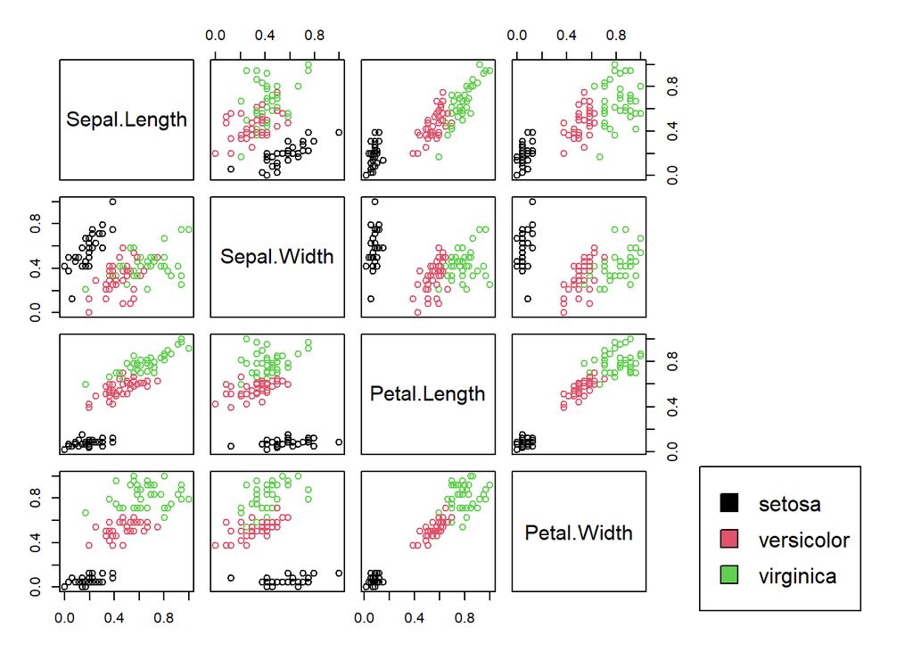

```r
trainReference <- cbind(trainingData,trainingLabels) # training data frame
pairs(trainReference[,1:4], col = trainReference[,5], oma=c(3,3,3,15))
par(xpd = TRUE)
legend("bottomright", fill = unique(trainReference[,5]),
       legend = c(levels(trainReference[,5])))
```

There is very clear segmentation with the iris data, we hope this translates well to our predictions.

### C. Apply the KNN algorithm

```
    1. k-nearest neighbors with iris - using the knn() function from the
    CLASS package. We will keep k odd to mitigate randomness introduced
    from tie-breaking. A confusion matrix is then created with the observed
    labels of the testing values compared against the KNN predicted labels:
```

```r
library(class) # for use of the knn() function
k1 <- round(sqrt(nrow(trainingData)))
if ((k1 %% 2) == 0) {k1 <- k1 + 1} # make sure k is odd
irisPrediction <- knn(train=trainingData, # training data
                      test=testingData, # testing data
                      cl=trainingLabels, # training labels
                      k=k1) # how many neighbors
pander(table(testingLabels,irisPrediction)) # confusion matrix
```

|  | setosa | versicolor | virginica |
| --- | --- | --- | --- |
| **setosa** | 15 | 0 | 0 |
| **versicolor** | 0 | 12 | 0 |
| **virginica** | 0 | 1 | 10 |

We only had 1 misfire: we predicted versicolor when it was in fact a virginica. Otherwise, very strong results from the algorithm: **37/38**

```
    2. Check accuracy with the confusionMatrix() function from the caret package
```

```r
library(caret) # for use of confusionMatrix()
cf1 <- confusionMatrix(testingLabels,irisPrediction)
print(paste(signif(cf1$overall[1],digits=3)*100,"% accurate."))
```

```
## [1] "97.4 % accurate."
```

We will now follow the same routines with the *fruits with colors* data.

### D. Prepare the fruit data for the KNN algorithm

```
    1. Pass the fruit data through the normalize() function, then view results
```

```r
fruitNormal <- fruit
fruitNormal[,1:4] <- as.data.frame(lapply(fruit[,1:4],normalize))
pander(summary(fruitNormal))
```

| mass | width | height | color_score | fruit_name |
| --- | --- | --- | --- | --- |
| Min. :0.0000 | Min. :0.0000 | Min. :0.0000 | Min. :0.0000 | apple :19 |
| 1st Qu.:0.2238 | 1st Qu.:0.2105 | 1st Qu.:0.4923 | 1st Qu.:0.4474 | lemon :16 |
| Median :0.2867 | Median :0.3684 | Median :0.5538 | Median :0.5263 | mandarin: 5 |
| Mean :0.3046 | Mean :0.3434 | Mean :0.5682 | Mean :0.5602 | orange :19 |
| 3rd Qu.:0.3531 | 3rd Qu.:0.4474 | 3rd Qu.:0.6462 | 3rd Qu.:0.6842 | NA |
| Max. :1.0000 | Max. :1.0000 | Max. :1.0000 | Max. :1.0000 | NA |

```
    3. Create training and testing data sets
```

```r
fruitLabels <- fruit[,5] # remember the original fruit labels
set.seed(1234) # for reproducibility
fruitIndex <- sample(nrow(fruitNormal), size = floor(0.75 * nrow(fruitNormal)))
trainingData2 <- fruitNormal[fruitIndex,1:4] # training data
trainingLabels2 <- fruitNormal[fruitIndex,5] # labels for the training data
testingData2 <- fruitNormal[-fruitIndex,1:4] # testing data 25% of original data
testingLabels2 <- fruitLabels[-fruitIndex] # labels for testing data
```

```
    4. Quick scatterplot matrix view of the training data
```

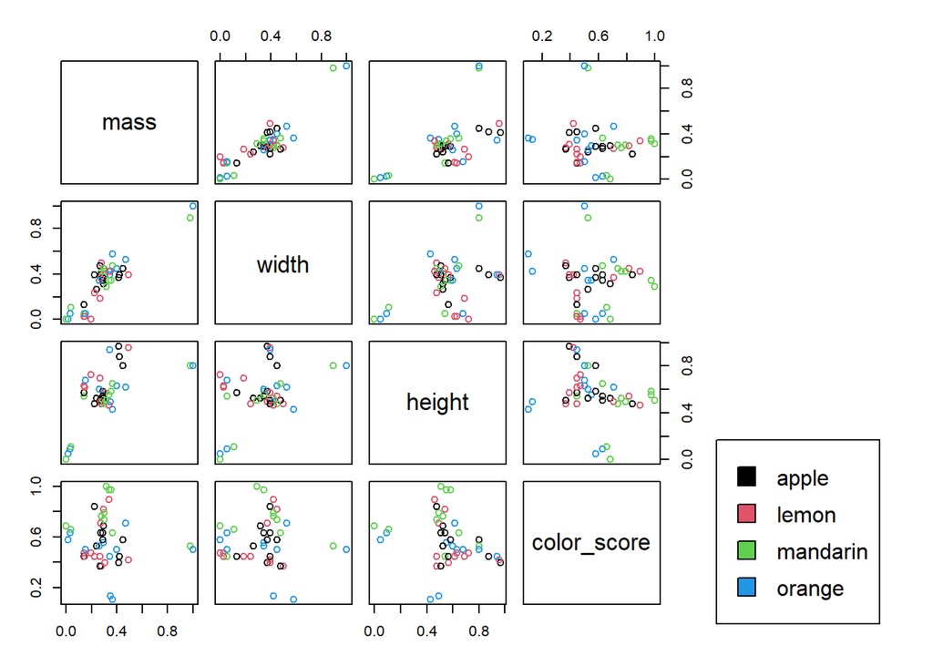

```r
trainReference2 <- cbind(trainingData2,trainingLabels2) # training data frame
pairs(trainReference2[,1:4], col = c(1:4), oma=c(3,3,3,15))
par(xpd = TRUE)
legend("bottomright", fill = c(1:4),
       legend = c(levels(trainReference2[,5])))
```

Unlike the *iris* data, segmentation is not visually obvious here. Will this impact our accuracy?

### C. Apply the KNN algorithm

```
    1. k-nearest neighbors with fruit
```

```r
k2 <- round(sqrt(nrow(trainingData2))) # make sure k is odd
if ((k2 %% 2) == 0) {k2 <- k2 + 1}
fruitPrediction1 <- knn(train=trainingData2,# training data
                      test=testingData2,  # testing data
                      cl=trainingLabels2,  # training labels
                      k=k2) # how many neighbors
pander(table(testingLabels2,fruitPrediction1)) # confusion matrix
```

|  | apple | lemon | mandarin | orange |
| --- | --- | --- | --- | --- |
| **apple** | 4 | 0 | 0 | 1 |
| **lemon** | 0 | 5 | 0 | 0 |
| **mandarin** | 0 | 0 | 1 | 0 |
| **orange** | 0 | 0 | 0 | 4 |

Like we saw with our *iris* predictions, only 1 bad prediction: we predicted orange when it was in fact an apple. Again, however, strong results: **14/15**

```
    2. Check accuracy
```

```r
cf2 <- confusionMatrix(testingLabels2,fruitPrediction1)
print(paste(signif(cf2$overall[1],digits=3)*100,"% accurate."))
```

```
## [1] "93.3 % accurate."
```

## II. Regression

Our aim with **regression** is to predict a numeric value. We will demonstrate regression with KNN using the *Housing Values in Suburbs of Boston* data from Harrison, D. and Rubinfeld, D.L. From this data, we will predict median home value from 13 predictors.

### A. Data to be used for regression

```
    1. ‘Housing Values in Suburbs of Boston’ data from Harrison, D. and
    Rubinfeld, D.L., 506 observations, from which we will predict median
    home value (medv)
```

Table continues below

| crim | zn | indus | chas | nox | rm | age | dis | rad | tax |
| --- | --- | --- | --- | --- | --- | --- | --- | --- | --- |
| 0.00632 | 18 | 2.31 | 0 | 0.538 | 6.575 | 65.2 | 4.09 | 1 | 296 |
| 0.02731 | 0 | 7.07 | 0 | 0.469 | 6.421 | 78.9 | 4.967 | 2 | 242 |
| 0.02729 | 0 | 7.07 | 0 | 0.469 | 7.185 | 61.1 | 4.967 | 2 | 242 |
| 0.03237 | 0 | 2.18 | 0 | 0.458 | 6.998 | 45.8 | 6.062 | 3 | 222 |
| 0.06905 | 0 | 2.18 | 0 | 0.458 | 7.147 | 54.2 | 6.062 | 3 | 222 |
| 0.02985 | 0 | 2.18 | 0 | 0.458 | 6.43 | 58.7 | 6.062 | 3 | 222 |

| ptratio | black | lstat | medv |
| --- | --- | --- | --- |
| 15.3 | 396.9 | 4.98 | 24 |
| 17.8 | 396.9 | 9.14 | 21.6 |
| 17.8 | 392.8 | 4.03 | 34.7 |
| 18.7 | 394.6 | 2.94 | 33.4 |
| 18.7 | 396.9 | 5.33 | 36.2 |
| 18.7 | 394.1 | 5.21 | 28.7 |

As done with the *iris* data and *fruits with colors*, we will normalize the 13 features, but not the response variable we are aiming to predict.

### B. Prepare the Boston data for the KNN algorithm

```
    1. Pass the Boston data through the normalize() function, then view results
```

```r
BostonNormal <- Boston
BostonNormal[,1:13] <- as.data.frame(lapply(BostonNormal[,1:13],normalize))
pander(summary(BostonNormal))
```

Table continues below

| crim | zn | indus | chas |
| --- | --- | --- | --- |
| Min. :0.0000000 | Min. :0.0000 | Min. :0.0000 | Min. :0.00000 |
| 1st Qu.:0.0008511 | 1st Qu.:0.0000 | 1st Qu.:0.1734 | 1st Qu.:0.00000 |
| Median :0.0028121 | Median :0.0000 | Median :0.3383 | Median :0.00000 |
| Mean :0.0405441 | Mean :0.1136 | Mean :0.3914 | Mean :0.06917 |
| 3rd Qu.:0.0412585 | 3rd Qu.:0.1250 | 3rd Qu.:0.6466 | 3rd Qu.:0.00000 |
| Max. :1.0000000 | Max. :1.0000 | Max. :1.0000 | Max. :1.00000 |

Table continues below

| nox | rm | age | dis |
| --- | --- | --- | --- |
| Min. :0.0000 | Min. :0.0000 | Min. :0.0000 | Min. :0.00000 |
| 1st Qu.:0.1317 | 1st Qu.:0.4454 | 1st Qu.:0.4338 | 1st Qu.:0.08826 |
| Median :0.3148 | Median :0.5073 | Median :0.7683 | Median :0.18895 |
| Mean :0.3492 | Mean :0.5219 | Mean :0.6764 | Mean :0.24238 |
| 3rd Qu.:0.4918 | 3rd Qu.:0.5868 | 3rd Qu.:0.9390 | 3rd Qu.:0.36909 |
| Max. :1.0000 | Max. :1.0000 | Max. :1.0000 | Max. :1.00000 |

Table continues below

| rad | tax | ptratio | black |
| --- | --- | --- | --- |
| Min. :0.0000 | Min. :0.0000 | Min. :0.0000 | Min. :0.0000 |
| 1st Qu.:0.1304 | 1st Qu.:0.1756 | 1st Qu.:0.5106 | 1st Qu.:0.9457 |
| Median :0.1739 | Median :0.2729 | Median :0.6862 | Median :0.9862 |
| Mean :0.3717 | Mean :0.4222 | Mean :0.6229 | Mean :0.8986 |
| 3rd Qu.:1.0000 | 3rd Qu.:0.9141 | 3rd Qu.:0.8085 | 3rd Qu.:0.9983 |
| Max. :1.0000 | Max. :1.0000 | Max. :1.0000 | Max. :1.0000 |

| lstat | medv |
| --- | --- |
| Min. :0.0000 | Min. : 5.00 |
| 1st Qu.:0.1440 | 1st Qu.:17.02 |
| Median :0.2657 | Median :21.20 |
| Mean :0.3014 | Mean :22.53 |
| 3rd Qu.:0.4201 | 3rd Qu.:25.00 |
| Max. :1.0000 | Max. :50.00 |

```
    3. Create training and testing data sets:
```

```r
BostonTargets <- BostonNormal[,14] # remember the original Boston targets
set.seed(1234) # for reproducibility
# indexes of random sample representing 75% of original data
BostonIndex <- sample(nrow(BostonNormal), size = floor(0.75 *
                                                         nrow(BostonNormal)))
trainingData3 <- BostonNormal[BostonIndex,1:13] # training data
trainingTargets <- BostonNormal[BostonIndex,14] # targets for the training data
testingData3 <- BostonNormal[-BostonIndex,1:13] # testing data 25% of original data
testingTargets <- BostonTargets[-BostonIndex] # labels for testing data
```

### C. Apply the KNN algorithm

```
    1. *k*-nearest neighbors with Boston - using the knn.reg() function from the FNN package
```

```r
library(FNN) # knn.reg()
BostonPredictions <- knn.reg(train=trainingData3,test=testingData3,
                             y=trainingTargets,k=11)
BostonP <- as.data.frame(cbind(testingTargets,
                               BostonPredictions$pred,
                               testingTargets-BostonPredictions$pred))
colnames(BostonP) <- c('observed','predicted','residuals')
pander(head(BostonP))
```

| observed | predicted | residuals |
| --- | --- | --- |
| 24 | 26.28 | -2.282 |
| 36.2 | 31.55 | 4.655 |
| 22.9 | 21.74 | 1.164 |
| 27.1 | 21.21 | 5.891 |
| 16.5 | 18.51 | -2.009 |
| 15 | 20.68 | -5.682 |

```
    2. A residual plot of the results from the KNN algorithm
```

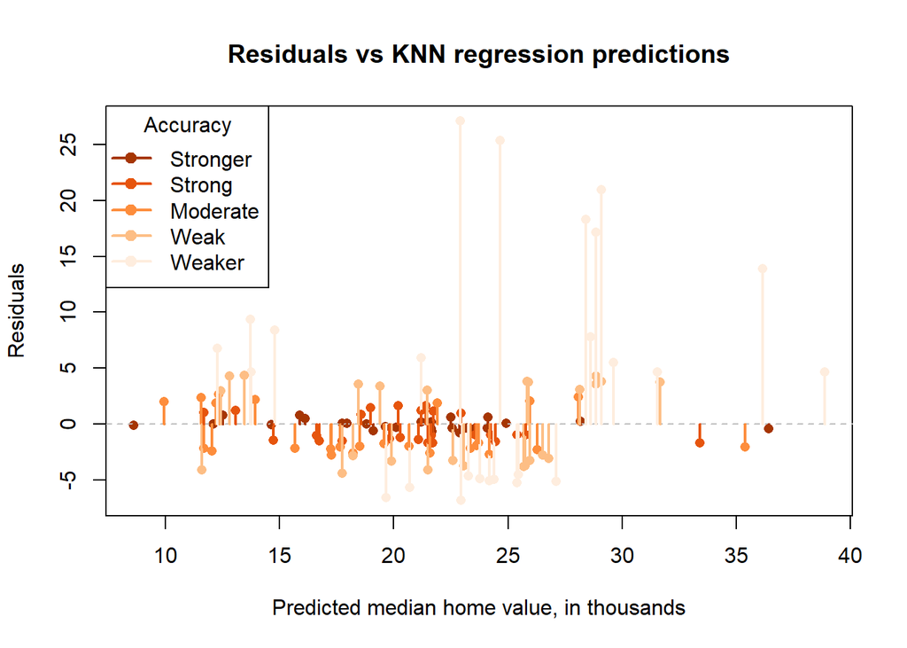

```r
# array of orange, dark-to-light
color <- c('#a63603','#e6550d','#fd8d3c','#fdbe85','#feedde')
# determine associated quantiles for color selection
z <- factor(cut(abs(BostonP$residuals),
                   quantile(abs(BostonP$residuals),
                            probs=seq(0,1,1/5)),
                   labels=FALSE,
                   include.lowest=TRUE))
# match color selection to fitted values for reference
levels(z) <- color
w <- cbind(as.vector(BostonPredictions$pred),
              as.vector(z))
plot(BostonPredictions$pred,
     BostonP$residuals,
     pch=16,col=w[,2],
     xlab="Predicted median home value, in thousands",
     ylab="Residuals",
     main="Residuals vs KNN regression predictions")
abline(h=0, lty=2, col='gray')
segments(x0=BostonPredictions$pred, # x position of fitted value
           y0=0, # start y-coordinate at 0
           x1=BostonPredictions$pred, # x position of fitted value
           y1=BostonP$residuals, # end y-coordinate at residual position
           lwd=2,
           col=w[,2])
legend('topleft',
         legend=c("Stronger", "Strong","Moderate","Weak","Weaker"),
         lwd=2,
         bg='white',
         col = color[1:5], # color range
         pch=19,
         title='Accuracy')
```

In a similar manner to how we might plot residuals vs. fitted values in linear regression, we have plotted residuals vs. our KNN predictions. The gradients denote relative accuracy between predictions, where weaker predictions are have lighter tones. Note that most predictions seem to be within a $5,000 range of those originally observed, though there are 6 or so predictions that appear significantly different than their observed values, possibly extremely so.

```r
mean(sapply(BostonP$residuals, abs))
```

```
## [1] 3.508017
```

Our mean difference in value (over or under) relying on KNN predictions was **$3,508**

```
    3. A residual plot from multiple linear regression
```

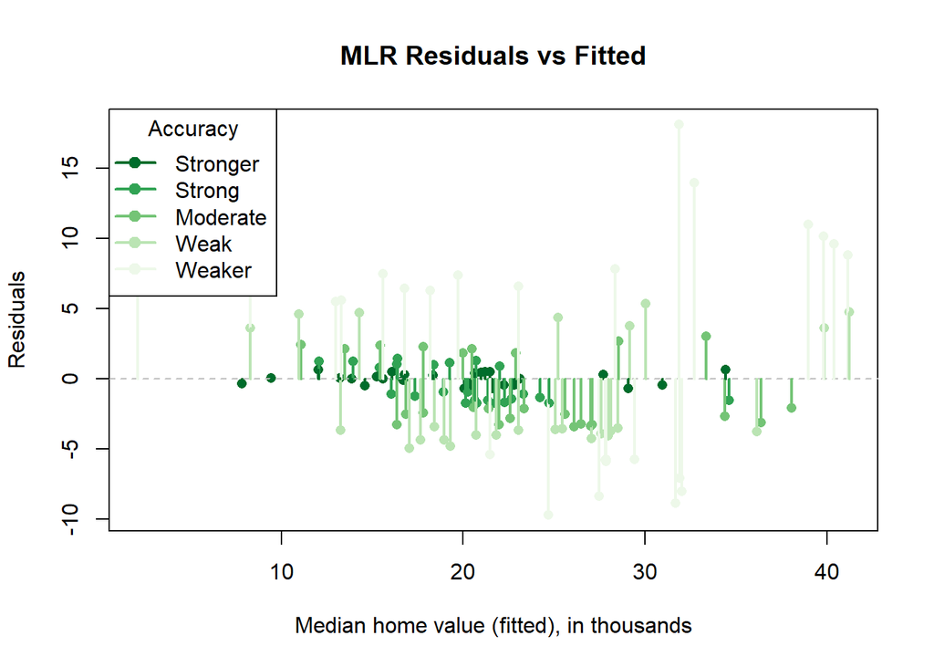

```r
# array of green, dark-to-light
color <- c('#006d2c','#31a354','#74c476','#bae4b3','#edf8e9')
tempFit <- lm(testingTargets ~ ., data=testingData3) # fit simple model
tempRes <- tempFit$residuals # residuals
# determine associated quantiles for color selection
z2 <- factor(cut(abs(tempRes),
                   quantile(abs(tempRes),
                            probs=seq(0,1,1/5)),
                   labels=FALSE,
                   include.lowest=TRUE))
# match color selection to fitted values for reference
levels(z2) <- color
w2 <- cbind(as.vector(fitted(tempFit)),
              as.vector(z2))
# base plot of the points
plot(w2[,1], tempRes, pch=16,
       col=w2[,2], # color of points
       xlab="Median home value (fitted), in thousands",
       ylab="Residuals",
       main="MLR Residuals vs Fitted")
# line at zero
abline(h=0, lty=2, col='gray')
# lines from centered line to plotted points
segments(x0=fitted(tempFit), # x position of fitted value
           y0=0, # start y-coordinate at 0
           x1=fitted(tempFit), # x position of fitted value
           y1=tempRes, # end y-coordinate at residual position
           lwd=2,
           col=w2[,2]) # color of drawn line segment
legend('topleft', # default or chosen legend position from function call
         legend=c("Stronger", "Strong","Moderate","Weak","Weaker"),
         lwd=2,
         bg='white',
         col = color[1:5], # color range
         pch=19,
         title='Accuracy')
```

Here we have residuals vs. fitted values from multiple linear regression. As with the prior plot, color gradients denote the relative accuracy of our fitted data in addition to the relative magnitude of residuals. As with KNN, most of the fitted values are within a range of $5,000 of the originally observed data. There are several fitted values that were far off from the original data, but none quite as extreme as the a few of the outlying predictions of our KNN results.

```r
mean(sapply(tempFit$residuals, abs))
```

```
## [1] 3.309115
```

Our mean difference in value (over or under) relying on MLR was **$3,309**

## Conclusion

**Classification** with *k*-nearest neighbors was quite accurate. In both of our test cases using the *iris* data and the *fruits with colors* data, we achieved over **93%** prediction accuracy. Often, it will be necessary to adjust the *k* value to achieve the best possible results as there is no guaranteed method for determining the optimal *k*. In our case, we did not have to fiddle with *k* to get satisfactory classification predictions.

**Regression** with *k*-nearest neighbors was serviceable, at the very least comparable to linear regression. In our test case with the *Boston* data, our most extreme KNN predictions were further away from the observed values than the fitted values from MLR. However, our overall mean difference in median home value between the predictions and observed values were still mostly similar. MLR was roughly **5.7%** closer to the true observed values of the homes, thus KNN had **6%** worse prediction accuracy (they differed by **$199**).

*k*-nearest neighbors appears to be a great tool for making rough predictions for both labels and numeric values. As a non-parametric statistical method, we do not need to satisfy assumptions typically required by statistical modeling techniques. Due to this fact, KNN seems well suited for real world data where a specific underlying distribution may not exist.

**References:**

[Fruit with colors dataset](https://www.kaggle.com/mjamilmoughal/fruits-with-colors-dataset/version/1)

[R Documentation - knn()](https://www.rdocumentation.org/packages/class/versions/7.3-19/topics/knn)

[R Documentation - knn.reg()](https://www.rdocumentation.org/packages/FNN/versions/1.1.3/topics/knn.reg)

[Analytics Vidhya - Best way to learn kNN Algorithm using R](https://www.analyticsvidhya.com/blog/2015/08/learning-concept-knn-algorithms-programming/)

[towards data science - K-nearest Neighbors Algorithm](https://towardsdatascience.com/k-nearest-neighbors-algorithm-with-examples-in-r-simply-explained-knn-1f2c88da405c)

[StackExchange - Which type of data normalizing should be used with KNN?](https://stats.stackexchange.com/questions/363889/which-type-of-data-normalizing-should-be-used-with-knn)